# DPRPy 2020/2021 Homework Assignment no. 3

Eray Tunç Yılmaz 295565 & Aytaç Gedik 301929

## **Required Libraries**

```r
library(xml2)
library(future)
library(rmarkdown)
library(knitr)
library(kableExtra)
library(sqldf)
library(wordcloud)
library(RColorBrewer)
library(TSstudio)
library(plotly)
library(lubridate)
```

## **Functions to Create Data Frame From XML File**

### Badges

```r
Badges <- function(path){
  #Path to XML file
  Badges_xml <- path

  #Read XML file
  Badges_doc <- read_xml(Badges_xml, useInternalNode = TRUE)

  #Get rows
  Badges_rows <- xml_children(Badges_doc)

  #Create data frame
  Badges_df <- data.frame(
    Id = as.integer(xml_attr(Badges_rows, "Id")),
    UserId = as.integer(xml_attr(Badges_rows, "UserId")),
    Name = as.character(xml_attr(Badges_rows, "Name")),
    Date = as.Date(xml_attr(Badges_rows, "Date")),
    Class = as.integer(xml_attr(Badges_rows, "Class")),
    TagBased = as.logical(xml_attr(Badges_rows, "TagBased")))

  return(Badges_df)}
```

### Comments

```r
Comments <- function(path){
  #Path to XML file
  Comments_xml <- path

  #Read XML file
  Comments_doc <- read_xml(Comments_xml, useInternalNode = TRUE)

  #Get rows
  Comments_rows <- xml_children(Comments_doc)

  #Create data frame
  Comments_df <- data.frame(
    Id = as.integer(xml_attr(Comments_rows, "Id")),
    PostId = as.integer(xml_attr(Comments_rows, "PostId")),
    Score = as.integer(xml_attr(Comments_rows, "Score")),
    Text = as.character(xml_attr(Comments_rows, "Text")),
    CreationDate = as.Date(xml_attr(Comments_rows, "CreationDate")),
    UserDisplayName = as.character(xml_attr(Comments_rows, "UserDisplayName")),
    UserId = as.integer(xml_attr(Comments_rows, "UserId")),
    ContentLicense = as.character(xml_attr(Comments_rows, "ContentLicense")))

  return(Comments_df)}
```

### PostHistory

```r
PostHistory <- function(path){
  #Path to XML file
  PostHistory_xml <- path

  #Read XML file
  PostHistory_doc <- read_xml(PostHistory_xml, useInternalNode = TRUE)

  #Get rows
  PostHistory_rows <- xml_children(PostHistory_doc)

  #Create data frame
  PostHistory_df <- data.frame(
    Id = as.integer(xml_attr(PostHistory_rows, "Id")),
    PostHistoryTypeId = as.integer(xml_attr(PostHistory_rows, "PostHistoryTypeId")),
    PostId = as.integer(xml_attr(PostHistory_rows, "PostId")),
    RevisionGUID = as.character(xml_attr(PostHistory_rows, "RevisionGUID")),
    CreationDate = as.Date(xml_attr(PostHistory_rows, "CreationDate")),
    UserId = as.integer(xml_attr(PostHistory_rows, "UserId")),
    UserDisplayName = as.character(xml_attr(PostHistory_rows, "UserDisplayName")),
    Comment = as.character(xml_attr(PostHistory_rows, "Comment")),
    Text = as.character(xml_attr(PostHistory_rows, "Text")),
    ContentLicense = as.character(xml_attr(PostHistory_rows, "ContentLicense")))

  return(PostHistory_df)}
```

### PostLinks

```r
PostLinks <- function(path){
  #Path to XML file
  PostLinks_xml <- path

  #Read XML file
  PostLinks_doc <- read_xml(PostLinks_xml, useInternalNode = TRUE)

  #Get rows
  PostLinks_rows <- xml_children(PostLinks_doc)

  #Create data frame
  PostLinks_df <- data.frame(
    Id = as.integer(xml_attr(PostLinks_rows, "Id")),
    CreationDate = as.Date(xml_attr(PostLinks_rows, "CreationDate")),
    PostId = as.integer(xml_attr(PostLinks_rows, "PostId")),
    RelatedPostId = as.integer(xml_attr(PostLinks_rows, "RelatedPostId")),
    LinkTypeId = as.integer(xml_attr(PostLinks_rows, "LinkTypeId")))

  return(PostLinks_df)}
```

### Posts

```r
Posts <- function(path){
  #Path to XML file
  Posts_xml <- path

  #Read XML file
  Posts_doc <- read_xml(Posts_xml, useInternalNode = TRUE)

  #Get rows
  Posts_rows <- xml_children(Posts_doc)

  #Create data frame
  Posts_df <- data.frame(
    Id = as.integer(xml_attr(Posts_rows, "Id")),
    PostTypeId = as.integer(xml_attr(Posts_rows, "PostTypeId")),
    AcceptedAnswerId = as.integer(xml_attr(Posts_rows, "AcceptedAnswerId")),
    ParentId = as.integer(xml_attr(Posts_rows, "ParentId")),
    CreationDate = as.Date(xml_attr(Posts_rows, "CreationDate")),
    Score = as.integer(xml_attr(Posts_rows, "Score")),
    ViewCount = as.integer(xml_attr(Posts_rows, "ViewCount")),
    Body = as.character(xml_attr(Posts_rows, "Body")),
    OwnerUserId = as.integer(xml_attr(Posts_rows, "OwnerUserId")),
    OwnerDisplayName = as.character(xml_attr(Posts_rows, "OwnerDisplayName")),
    LastEditorUserId = as.integer(xml_attr(Posts_rows, "LastEditorUserId")),
    LastEditorDisplayName = as.character(xml_attr(Posts_rows, "LastEditorDisplayName")),
    LastEditDate = as.Date(xml_attr(Posts_rows, "LastEditDate")),
    LastActivityDate = as.Date(xml_attr(Posts_rows, "LastActivityDate")),
    Title = as.character(xml_attr(Posts_rows, "Title")),
    Tags = as.character(xml_attr(Posts_rows, "Tags")),
    AnswerCount = as.integer(xml_attr(Posts_rows, "AnswerCount")),
    CommentCount = as.integer(xml_attr(Posts_rows, "CommentCount")),
    FavoriteCount = as.integer(xml_attr(Posts_rows, "FavoriteCount")),
    ClosedDate = as.Date(xml_attr(Posts_rows, "ClosedDate")),
    CommunityOwnedDate = as.Date(xml_attr(Posts_rows, "CommunityOwnedDate")),
    ContentLicense = as.character(xml_attr(Posts_rows, "ContentLicense")))

  return(Posts_df)}
```

### Tags

```r
Tags <- function(path){
  #Path to XML file
  Tags_xml <- path

  #Read XML files
  Tags_doc <- read_xml(Tags_xml, useInternalNode = TRUE)

  #Get rows
  Tags_rows <- xml_children(Tags_doc)

  #Create data frame
  Tags_df <- data.frame(
    Id = as.integer(xml_attr(Tags_rows, "Id")),
    TagName = as.character(xml_attr(Tags_rows, "TagName")),
    Count = as.integer(xml_attr(Tags_rows, "Count")),
    ExcerptPostId = as.integer(xml_attr(Tags_rows, "ExcerptPostId")),
    WikiPostId = as.integer(xml_attr(Tags_rows, "WikiPostId")))

  return(Tags_df)}
```

### Users

```r
Users <- function(path){
  #Path to XML file
  Users_xml <- path

  #Read XML files
  Users_doc <- read_xml(Users_xml, useInternalNode = TRUE)

  #Get rows
  Users_rows <- xml_children(Users_doc)

  #Create data frame
  Users_df <- data.frame(
    Id = as.integer(xml_attr(Users_rows, "Id")),
    Reputation = as.integer(xml_attr(Users_rows, "Reputation")),
    CreationDate = as.Date(xml_attr(Users_rows, "CreationDate")),
    DisplayName = as.character(xml_attr(Users_rows, "DisplayName")),
    LastAccessDate = as.Date(xml_attr(Users_rows, "LastAccessDate")),
    WebsiteUrl = as.character(xml_attr(Users_rows, "WebsiteUrl")),
    Location = as.character(xml_attr(Users_rows, "Location")),
    AboutMe = as.character(xml_attr(Users_rows, "AboutMe")),
    Views = as.integer(xml_attr(Users_rows, "Views")),
    UpVotes = as.integer(xml_attr(Users_rows, "UpVotes")),
    DownVotes = as.integer(xml_attr(Users_rows, "DownVotes")),
    ProfileImageUrl = as.character(xml_attr(Users_rows, "ProfileImageUrl")),
    AccountId = as.integer(xml_attr(Users_rows, "AccountId")))

  return(Users_df)}
```

### Votes

```r
Votes <- function(path){
  #Path to XML file
  Votes_xml <- path

  #Read XML files
  Votes_doc <- read_xml(Votes_xml, useInternalNode = TRUE)

  #Get rows
  Votes_rows <- xml_children(Votes_doc)

  #Create data frame
  Votes_df <- data.frame(
    Id = as.integer(xml_attr(Votes_rows, "Id")),
    PostId = as.integer(xml_attr(Votes_rows, "PostId")),
    VoteTypeId = as.integer(xml_attr(Votes_rows, "VoteTypeId")),
    UserId = as.integer(xml_attr(Votes_rows, "UserId")),
    CreationDate = as.Date(xml_attr(Votes_rows, "CreationDate")),
    BountyAmount = as.integer(xml_attr(Votes_rows, "BountyAmount")))

  return(Votes_df)}
```

## **Visualizing Functions**

### Data Viewer

```r
#For a quick look at the data frame. Top 10 rows are shown.
Data_View <- function(df, cptn, algnmnt)
  kable(head(df, n = 10), caption = cptn, align = algnmnt) %>%
  kable_styling(bootstrap_options = c('striped', 'hover', 'responsive', 'condensed')) %>%
  scroll_box(width = "100%", height = "200px")
```

## **Auxiliary Functions**

### Order by

```r
#Returns a data frame where it is ordered according to given column
Order_By <- function(df, col)
  sqldf::sqldf(sprintf("
  SELECT
      *
  FROM
      %s
  ORDER BY
      %s DESC
  ", df, col))
```

### Top Answerers

```r
#Returns a data frame of users ordered according to their scores.
Top_Answerers <- function(Users_df, Posts_df)
  sqldf::sqldf("
  SELECT
      Users_df.Id,
      DisplayName,
      Count(Posts_df.Id) AS Answers,
      CAST(AVG(CAST(Score AS float)) as numeric(6,2)) AS [Average Answer Score]
  FROM
      Posts_df
  INNER JOIN
      Users_df ON Users_df.Id = OwnerUserId
  WHERE
      PostTypeId = 2 and CommunityOwnedDate IS NULL and ClosedDate IS NULL
  GROUP BY
      Users_df.Id, DisplayName
  HAVING
      Count(Posts_df.Id) > 10
  ORDER BY
      [Average Answer Score] DESC
  ")
```

### Most Used Tags

```r
#Returns a data frame where tags are ordered according to their usage counts.
Words <- function(Tags_df)
  sqldf::sqldf("
  SELECT
      TagName,
      Count
  FROM
      Tags_df
  ORDER BY
      Count DESC
  ")
```

### Top Users by Country

```r
#Returns a data frame of users ordered by their reputation of given country.
Top_Users <- function(Users_df, Country)
  sqldf::sqldf(sprintf("
  SELECT
      ROW_NUMBER() OVER(ORDER BY Reputation DESC) AS [#],
      Id,
      DisplayName,
      Reputation
  FROM
      %s
  WHERE
      LOWER(Location) LIKE LOWER('%s')
  ORDER BY
      Reputation DESC
  ", Users_df, Country))
```

## **android.stackexchange.com**

### Path to android XML files

```r
android_Badges_xml <- "android.stackexchange.com\\Badges.xml"
android_Comments_xml <- "android.stackexchange.com\\Comments.xml"
android_PostHistory_xml <- "android.stackexchange.com\\PostHistory.xml"
android_PostLinks_xml <- "android.stackexchange.com\\PostLinks.xml"
android_Posts_xml <- "android.stackexchange.com\\Posts.xml"
android_Tags_xml <- "android.stackexchange.com\\Tags.xml"
android_Users_xml <- "android.stackexchange.com\\Users.xml"
android_Votes_xml <- "android.stackexchange.com\\Votes.xml"
```

### Data Frames

```r
#Data frames will be created in parallel. Hence, creating multisession
plan(multisession, gc = TRUE)

#Promises
android_Badges_df %<-% Badges(android_Badges_xml)
android_Comments_df %<-% Comments(android_Comments_xml)
android_PostHistory_df %<-% PostHistory(android_PostHistory_xml)
android_PostLinks_df %<-% PostLinks(android_PostLinks_xml)
android_Posts_df %<-% Posts(android_Posts_xml)
android_Tags_df %<-% Tags(android_Tags_xml)
android_Users_df %<-% Users(android_Users_xml)
android_Votes_df %<-% Votes(android_Votes_xml)

#Creating data frames
android_dfs <- lapply(ls(pattern = "android"), get)

#Continue rest in sequential
plan(sequential)
```

##### The most viewed question being How to bypass “Verify your account” (Factory Reset Protection) is created on 2015-11-02 has 2991815 views.

##### Following the first question, most viewed second and third questions are Google Play Services Has stopped message continually popping up on my Samsung phone is created on 2015-09-12 has 2719953 views and How to use Windows’ internet on Android phone through USB cable is created on 2014-06-14 has 1460380 views.

##### Also, the highest scored question How do I root my Android device? with 491 points is created on 2010-09-19.

##### After the first question, second and third one are How to fully backup non-rooted devices? with 334 points is created on 2012-08-26 and I’ve rooted my phone. Now what? What do I gain from rooting? with 308 points is created on 2010-09-13.

##### Next, the Top 10 Users on android.stackexchange.com based on their reputations is shown on the below.

```r
Data_View(Order_By("android_Users_df", "Reputation")[1:10, c("Id", "DisplayName", "Reputation")], 'Top 10 Users', "clc")
```

Top 10 Users

| Id | DisplayName | Reputation |
| --- | --- | --- |
| 16575 | Izzy | 85729 |
| 1465 | Matthew Read | 49680 |
| 981 | eldarerathis | 36111 |
| 12442 | Dan Hulme | 33595 |
| 131553 | beeshyams | 33346 |
| 1951 | Ryan Conrad | 22098 |
| 156 | GAThrawn | 21884 |
| 10 | Bryan Denny | 21747 |
| 96277 | Firelord | 21372 |
| 267 | ale | 19594 |

##### Also, on the figure below the Top 10 Poland Users is shown.

```r
Data_View(Top_Users("android_Users_df", "Poland"), 'Top 10 Poland Users', "cclc")
```

Top 10 Poland Users

| # | Id | DisplayName | Reputation |
| --- | --- | --- | --- |
| 1 | 114127 | Arielle | 737 |
| 2 | 177898 | pzmarzly | 446 |
| 3 | 222586 | Agent_L | 301 |
| 4 | 77154 | QkiZ | 237 |
| 5 | 84816 | PolGraphic | 230 |
| 6 | 69060 | gronostaj | 227 |
| 7 | 76271 | tomash | 216 |
| 8 | 22449 | K.L. | 193 |
| 9 | 12586 | Grzegorz | 191 |
| 10 | 17096 | GDR | 191 |

##### Exploring more, the Top 10 Answerers on android.stackexchange.com is shown on the below figure.

```r
Data_View(Top_Answerers(android_Users_df, android_Posts_df), 'Top Answerers', "llcc")
```

Top Answerers

| Id | DisplayName | Answers | Average Answer Score |
| --- | --- | --- | --- |
| 55397 | Min Naing Oo | 13 | 16.615385 |
| 12711 | davidbb | 11 | 8.636364 |
| 19 | Dan Dyer | 11 | 7.272727 |
| 45 | Rohan Singh | 18 | 7.055556 |
| 10040 | joweiser | 12 | 6.500000 |
| 981 | eldarerathis | 455 | 6.430769 |
| 5132 | bmaupin | 31 | 6.322581 |
| 11251 | Sergey Vlasov | 34 | 6.176471 |
| 10050 | Martin | 13 | 5.846154 |
| 1274 | Matt H | 37 | 5.702703 |

##### There are total of 1470 different Tags on android.stackexchange.com and the most used tags on android.stackexchange.com are shown as word cloud below.

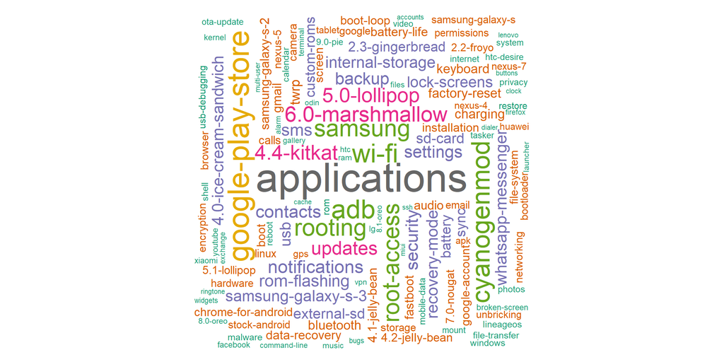

```r
#Word Cloud
wordcloud(words = Words(android_Tags_df)$TagName, freq = Words(android_Tags_df)$Count, min.freq = 1, max.words = 200, random.order = FALSE, rot.per = 0.35, colors = brewer.pal(8, "Dark2"))
```

## **apple.stackexchange.com**

### Path to apple XML files

```r
apple_Badges_xml <- "apple.stackexchange.com\\Badges.xml"
apple_Comments_xml <- "apple.stackexchange.com\\Comments.xml"
apple_PostHistory_xml <- "apple.stackexchange.com\\PostHistory.xml"
apple_PostLinks_xml <- "apple.stackexchange.com\\PostLinks.xml"
apple_Posts_xml <- "apple.stackexchange.com\\Posts.xml"
apple_Tags_xml <- "apple.stackexchange.com\\Tags.xml"
apple_Users_xml <- "apple.stackexchange.com\\Users.xml"
apple_Votes_xml <- "apple.stackexchange.com\\Votes.xml"
```

### Data Frames

```r
#Data frames will be created in parallel. Hence, creating multisession
plan(multisession, gc = TRUE)

#Promises
apple_Badges_df %<-% Badges(apple_Badges_xml)
apple_Comments_df %<-% Comments(apple_Comments_xml)
apple_PostHistory_df %<-% PostHistory(apple_PostHistory_xml)
apple_PostLinks_df %<-% PostLinks(apple_PostLinks_xml)
apple_Posts_df %<-% Posts(apple_Posts_xml)
apple_Tags_df %<-% Tags(apple_Tags_xml)
apple_Users_df %<-% Users(apple_Users_xml)
apple_Votes_df %<-% Votes(apple_Votes_xml)

#Creating data frames
apple_dfs <- lapply(ls(pattern = "apple"), get)

#Continue rest in sequential
plan(sequential)
```

##### The most viewed question being Is there any way to view saved wifi passwords on the iPhone? is created on 2012-06-23 has 2709330 views.

##### Following the first question, most viewed second and third questions are What does it mean when an iMessage doesn’t say “Delivered” nor “Not Delivered”? is created on 2012-08-03 has 2246210 views and Stop iMessages from coming to my Mac is created on 2012-12-08 has 1743891 views.

##### Also, the highest scored question Why am I getting an “invalid active developer path” when attempting to use Git after upgrading to macOS Catalina? with 1828 points is created on 2016-09-24.

##### After the first question, second and third one are List of all packages installed using Homebrew with 584 points is created on 2013-09-06 and Please share your hidden macOS features or tips and tricks with 583 points is created on 2010-08-24.

##### Next, the Top 10 Users on apple.stackexchange.com based on their reputations is shown on the below.

```r
Data_View(Order_By("apple_Users_df", "Reputation")[1:10, c("Id", "DisplayName", "Reputation")], 'Top 10 Users', "clc")
```

Top 10 Users

| Id | DisplayName | Reputation |
| --- | --- | --- |
| 5472 | bmike | 197630 |
| 37797 | grg | 161509 |
| 3936 | Lri | 89735 |
| 85275 | Tetsujin | 80769 |
| 119271 | Allan | 72518 |
| 9058 | nohillside | 69668 |
| 93229 | klanomath | 60148 |
| 168832 | Monomeeth | 58259 |
| 77912 | jksoegaard | 45193 |
| 13414 | gentmatt | 43906 |

##### Also, on the figure below the Top 10 Poland Users is shown.

```r
Data_View(Top_Users("apple_Users_df", "Poland"), 'Top 10 Poland Users', "cclc")
```

Top 10 Poland Users

| # | Id | DisplayName | Reputation |
| --- | --- | --- | --- |
| 1 | 2698 | Michal M | 3716 |
| 2 | 54949 | Paul Brewczynski | 1949 |
| 3 | 36467 | maseth | 1359 |
| 4 | 50394 | cubuspl42 | 700 |
| 5 | 1928 | MadBoy | 673 |
| 6 | 15402 | kars7e | 420 |
| 7 | 288279 | Minorite | 381 |
| 8 | 66114 | enedil | 337 |
| 9 | 296793 | Ancinek | 253 |
| 10 | 349457 | ikurek | 224 |

##### Exploring more, the Top 10 Answerers on apple.stackexchange.com is shown on the below figure.

```r
Data_View(Top_Answerers(apple_Users_df, apple_Posts_df), 'Top Answerers', "llcc")
```

Top Answerers

| Id | DisplayName | Answers | Average Answer Score |
| --- | --- | --- | --- |
| 988 | Gilles ‘SO- stop being evil’ | 16 | 36.50000 |
| 24565 | Michael Durrant | 23 | 28.21739 |
| 2190 | boehj | 14 | 26.35714 |
| 11169 | cm2 | 14 | 23.85714 |
| 10193 | mluisbrown | 15 | 19.00000 |
| 39878 | matt burns | 14 | 17.92857 |
| 48207 | malhal | 11 | 16.27273 |
| 2643 | jstarek | 14 | 16.21429 |
| 2352 | Brant Bobby | 11 | 15.90909 |
| 24130 | nwinkler | 27 | 14.44444 |

##### There are total of 1040 different Tags on apple.stackexchange.com and the most used tags on apple.stackexchange.com are shown as word cloud below.

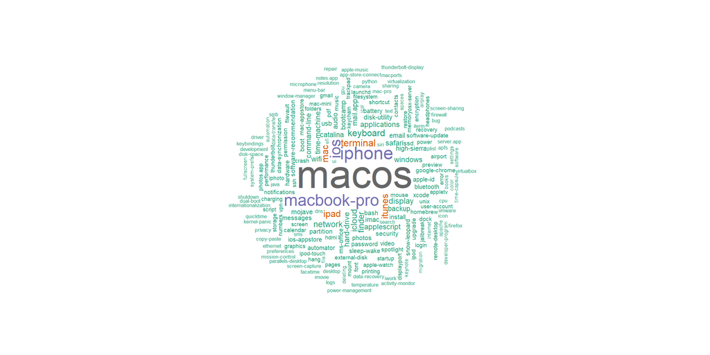

```r
#Word Cloud
wordcloud(words = Words(apple_Tags_df)$TagName, freq = Words(apple_Tags_df)$Count, min.freq = 1, max.words = 200, random.order = FALSE, rot.per = 0.35, colors = brewer.pal(8, "Dark2"))
```

## **gaming.stackexchange.com**

### Path to gaming XML files

```r
gaming_Badges_xml <- "gaming.stackexchange.com\\Badges.xml"
gaming_Comments_xml <- "gaming.stackexchange.com\\Comments.xml"
gaming_PostHistory_xml <- "gaming.stackexchange.com\\PostHistory.xml"
gaming_PostLinks_xml <- "gaming.stackexchange.com\\PostLinks.xml"
gaming_Posts_xml <- "gaming.stackexchange.com\\Posts.xml"
gaming_Tags_xml <- "gaming.stackexchange.com\\Tags.xml"
gaming_Users_xml <- "gaming.stackexchange.com\\Users.xml"
gaming_Votes_xml <- "gaming.stackexchange.com\\Votes.xml"
```

### Data Frames

```r
#Data frames will be created in parallel. Hence, creating multisession
plan(multisession, gc = TRUE)

#Promises
gaming_Badges_df %<-% Badges(gaming_Badges_xml)
gaming_Comments_df %<-% Comments(gaming_Comments_xml)
gaming_PostHistory_df %<-% PostHistory(gaming_PostHistory_xml)
gaming_PostLinks_df %<-% PostLinks(gaming_PostLinks_xml)
gaming_Posts_df %<-% Posts(gaming_Posts_xml)
gaming_Tags_df %<-% Tags(gaming_Tags_xml)
gaming_Users_df %<-% Users(gaming_Users_xml)
gaming_Votes_df %<-% Votes(gaming_Votes_xml)

#Creating data frames
gaming_dfs <- lapply(ls(pattern = "gaming"), get)

#Continue rest in sequential
plan(sequential)
```

##### The most viewed question being How can I get more headshots? is created on 2013-07-03 has 2447017 views.

##### Following the first question, most viewed second and third questions are Keep items in inventory on death in Minecraft is created on 2012-11-26 has 1654165 views and How do I deliver a baby? is created on 2015-06-15 has 1552294 views.

##### Also, the highest scored question How can I tell if a corpse is safe to eat? with 472 points is created on 2010-08-10.

##### After the first question, second and third one are Is Angry Birds deterministic? with 369 points is created on 2011-12-29 and What’s the most efficient Minecraft mining strategy? with 326 points is created on 2010-10-01.

##### Next, the Top 10 Users on gaming.stackexchange.com based on their reputations is shown on the below.

```r
Data_View(Order_By("gaming_Users_df", "Reputation")[1:10, c("Id", "DisplayName", "Reputation")], 'Top 10 Users', "clc")
```

Top 10 Users

| Id | DisplayName | Reputation |
| --- | --- | --- |
| 336 | Raven Dreamer | 164880 |
| 13845 | agent86 | 117015 |
| 3917 | l I | 80507 |
| 3129 | LessPop_MoreFizz | 73301 |
| 52800 | kalina | 71971 |
| 18916 | sayu | 68216 |
| 4103 | Mad Scientist | 63738 |
| 162442 | Vemonus | 61544 |
| 1719 | Invader Skoodge | 61243 |
| 122 | Oak | 56838 |

##### Also, on the figure below the Top 10 Poland Users is shown.

```r
Data_View(Top_Users("gaming_Users_df", "Poland"), 'Top 10 Poland Users', "cclc")
```

Top 10 Poland Users

| # | Id | DisplayName | Reputation |
| --- | --- | --- | --- |
| 1 | 77 | Piaskal | 1446 |
| 2 | 28335 | Shaamaan | 767 |
| 3 | 42535 | Maurycy | 761 |
| 4 | 7053 | lauriys | 742 |
| 5 | 64265 | cubuspl42 | 725 |
| 6 | 67112 | z33k | 537 |
| 7 | 4169 | silk | 489 |
| 8 | 115 | DzinX | 463 |
| 9 | 122302 | MatthewRock | 434 |
| 10 | 27388 | Konrad Borowski | 430 |

##### Exploring more, the Top 10 Answerers on gaming.stackexchange.com is shown on the below figure.

```r
Data_View(Top_Answerers(gaming_Users_df, gaming_Posts_df), 'Top Answerers', "llcc")
```

Top Answerers

| Id | DisplayName | Answers | Average Answer Score |
| --- | --- | --- | --- |
| 12779 | Pubby | 15 | 21.60000 |
| 102420 | udondan | 15 | 17.20000 |
| 117670 | Exerion | 14 | 14.92857 |
| 1410 | WillfulWizard | 71 | 14.00000 |
| 8239 | Tom Grochowicz | 32 | 13.81250 |
| 7364 | BoltClock | 43 | 13.69767 |
| 6914 | Arkive | 66 | 13.62121 |
| 3720 | Andrzej Doyle | 13 | 13.53846 |
| 6425 | zzzzBov | 15 | 13.53333 |
| 112 | ire_and_curses | 18 | 13.16667 |

##### There are total of 5488 different Tags on gaming.stackexchange.com and the most used tags on gaming.stackexchange.com are shown as word cloud below.

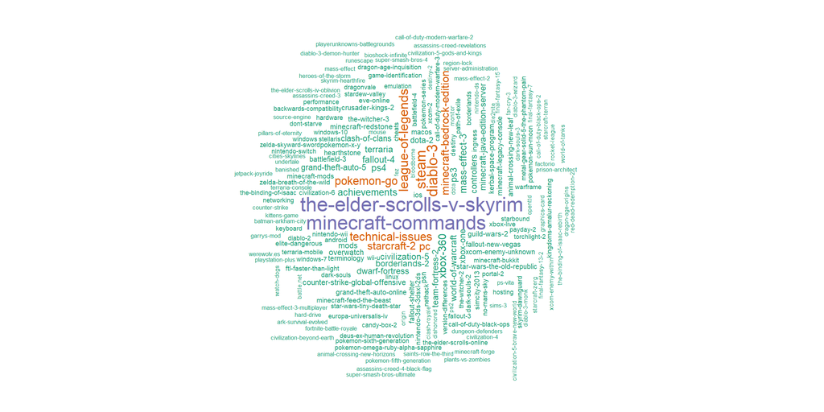

```r
#Word Cloud
wordcloud(words = Words(gaming_Tags_df)$TagName, freq = Words(gaming_Tags_df)$Count, min.freq = 1, max.words = 200, random.order = FALSE, rot.per = 0.35, colors = brewer.pal(8, "Dark2"))
```

## **gamedev.stackexchange.com**

### Path to gamedev XML files

```r
gamedev_Badges_xml <- "gamedev.stackexchange.com\\Badges.xml"
gamedev_Comments_xml <- "gamedev.stackexchange.com\\Comments.xml"
gamedev_PostHistory_xml <- "gamedev.stackexchange.com\\PostHistory.xml"
gamedev_PostLinks_xml <- "gamedev.stackexchange.com\\PostLinks.xml"
gamedev_Posts_xml <- "gamedev.stackexchange.com\\Posts.xml"
gamedev_Tags_xml <- "gamedev.stackexchange.com\\Tags.xml"
gamedev_Users_xml <- "gamedev.stackexchange.com\\Users.xml"
gamedev_Votes_xml <- "gamedev.stackexchange.com\\Votes.xml"
```

### Data Frames

```r
#Data frames will be created in parallel. Hence, creating multisession
plan(multisession, gc = TRUE)

#Promises
gamedev_Badges_df %<-% Badges(gamedev_Badges_xml)
gamedev_Comments_df %<-% Comments(gamedev_Comments_xml)
gamedev_PostHistory_df %<-% PostHistory(gamedev_PostHistory_xml)
gamedev_PostLinks_df %<-% PostLinks(gamedev_PostLinks_xml)
gamedev_Posts_df %<-% Posts(gamedev_Posts_xml)
gamedev_Tags_df %<-% Tags(gamedev_Tags_xml)
gamedev_Users_df %<-% Users(gamedev_Users_xml)
gamedev_Votes_df %<-% Votes(gamedev_Votes_xml)

#Creating data frames
gamedev_dfs <- lapply(ls(pattern = "gamedev"), get)

#Continue rest in sequential
plan(sequential)
```

##### The most viewed question being How do I get started making Android games? is created on 2010-08-31 has 256084 views.

##### Following the first question, most viewed second and third questions are How to merge two objects in Blender is created on 2012-08-08 has 254877 views and Where can I find free music for my game? is created on 2010-07-14 has 245921 views.

##### Also, the highest scored question How can I effectively manage a hobby game project? with 429 points is created on 2010-07-14.

##### After the first question, second and third one are What are good games to “earn your wings” with? with 310 points is created on 2010-07-21 and How can I find an optimum set of colors for 10 players? with 298 points is created on 2012-12-29.

##### Next, the Top 10 Users on gamedev.stackexchange.com based on their reputations is shown on the below.

```r
Data_View(Order_By("gamedev_Users_df", "Reputation")[1:10, c("Id", "DisplayName", "Reputation")], 'Top 10 Users', "clc")
```

Top 10 Users

| Id | DisplayName | Reputation |
| --- | --- | --- |
| 21890 | Philipp | 100267 |
| 39518 | DMGregory | 92769 |
| 7191 | MichaelHouse | 71873 |
| 7697 | Sean Middleditch | 40794 |
| 9894 | Nathan Reed | 32609 |
| 51 | Tetrad | 29957 |
| 5473 | Engineer | 28085 |
| 8240 | Nicol Bolas | 25350 |
| 11686 | David Gouveia | 24457 |
| 1101 | Kylotan | 23710 |

##### Also, on the figure below the Top 10 Poland Users is shown.

```r
Data_View(Top_Users("gamedev_Users_df", "Poland"), 'Top 10 Poland Users', "cclc")
```

Top 10 Poland Users

| # | Id | DisplayName | Reputation |
| --- | --- | --- | --- |
| 1 | 12406 | dreta | 3494 |
| 2 | 23182 | PolGraphic | 900 |
| 3 | 33715 | K.L. | 745 |
| 4 | 24464 | tobi | 699 |
| 5 | 91572 | tc07 | 445 |
| 6 | 5163 | m4tx | 417 |
| 7 | 44157 | Winged | 340 |
| 8 | 18245 | lampak | 271 |
| 9 | 34327 | luke1985 | 267 |
| 10 | 39222 | MatthewRock | 260 |

##### Exploring more, the Top 10 Answerers on gamedev.stackexchange.com is shown on the below figure.

```r
Data_View(Top_Answerers(gamedev_Users_df, gamedev_Posts_df), 'Top Answerers', "llcc")
```

Top Answerers

| Id | DisplayName | Answers | Average Answer Score |
| --- | --- | --- | --- |
| 102849 | altskop | 12 | 17.41667 |
| 160 | munificent | 60 | 15.96667 |
| 165 | Cyclops | 14 | 15.85714 |
| 3318 | Michael Madsen | 11 | 14.54545 |
| 16587 | MLM | 11 | 13.81818 |
| 9016 | Raphael R. | 11 | 13.36364 |
| 323 | ZorbaTHut | 76 | 13.05263 |
| 16498 | XenoRo | 16 | 12.06250 |
| 120 | Cubed2D | 11 | 12.00000 |
| 7881 | dlras2 | 18 | 11.94444 |

##### There are total of 1075 different Tags on gamedev.stackexchange.com and the most used tags on gamedev.stackexchange.com are shown as word cloud below.

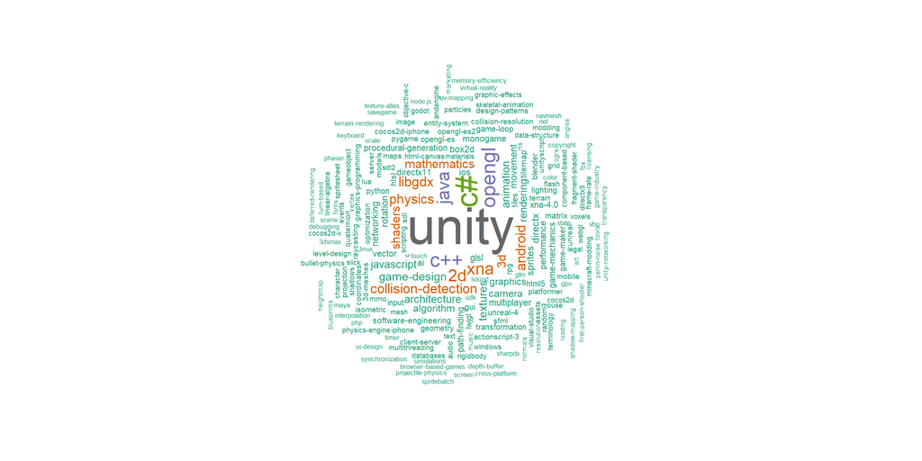

```r
#Word Cloud
wordcloud(words = Words(gamedev_Tags_df)$TagName, freq = Words(gamedev_Tags_df)$Count, min.freq = 1, max.words = 200, random.order = FALSE, rot.per = 0.35, colors = brewer.pal(8, "Dark2"))
```